# Notes on Statistics

# Part I: Basics

Sample data `cars` : speed (mph), stop distance (ft)

```r
head(cars)
```

```
##   speed dist
## 1     4    2
## 2     4   10
## 3     7    4
## 4     7   22
## 5     8   16
## 6     9   10
```

```r
(n <- nrow(cars))
```

```
## [1] 50
```

```r
x <- cars$speed
y <- cars$dist
```

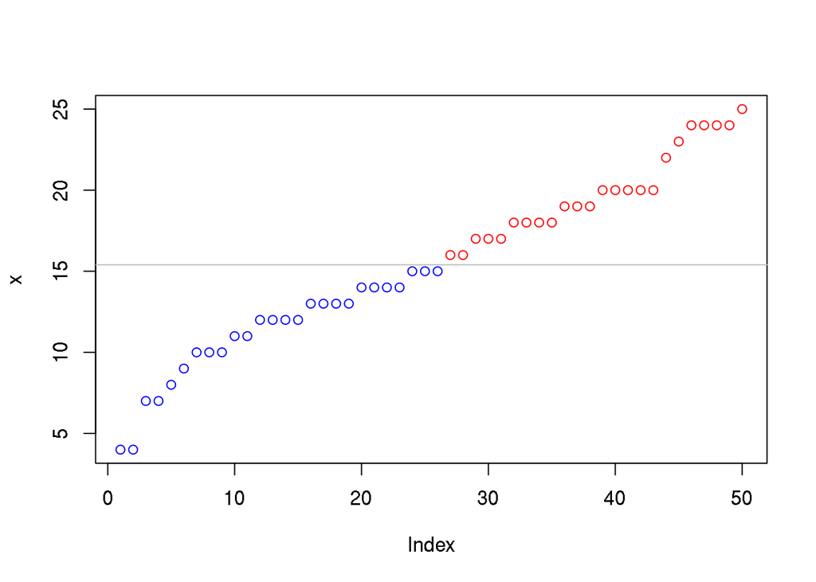

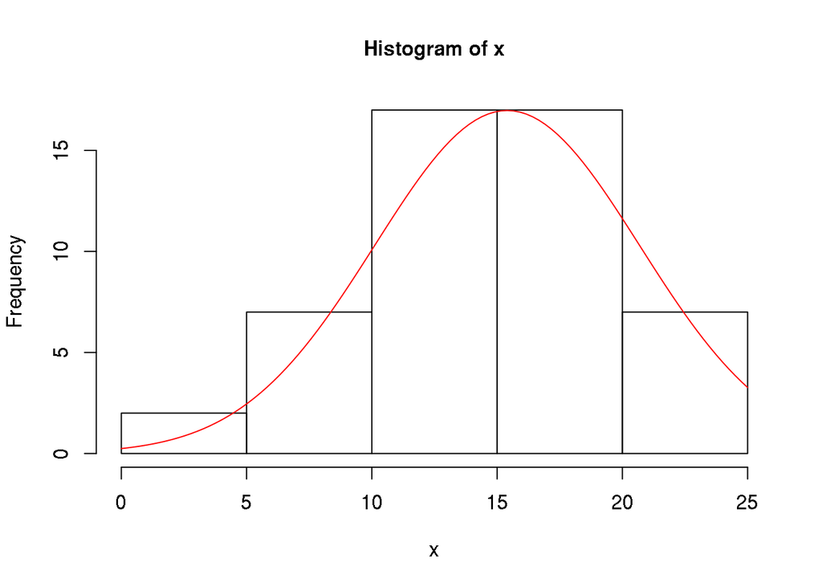

```r
summary(cars)
```

```
##      speed           dist
##  Min.   : 4.0   Min.   :  2.00
##  1st Qu.:12.0   1st Qu.: 26.00
##  Median :15.0   Median : 36.00
##  Mean   :15.4   Mean   : 42.98
##  3rd Qu.:19.0   3rd Qu.: 56.00
##  Max.   :25.0   Max.   :120.00
```

Stem-and-leaf

```r
stem(x)
```

```
##
##   The decimal point is at the |
##
##    4 | 00
##    6 | 00
##    8 | 00
##   10 | 00000
##   12 | 00000000
##   14 | 0000000
##   16 | 00000
##   18 | 0000000
##   20 | 00000
##   22 | 00
##   24 | 00000
```

## Mean (1st moment)

```r
sum(x) / n
```

```
## [1] 15.4
```

```r
(x.mean <- mean(x))
```

```
## [1] 15.4
```

MA:

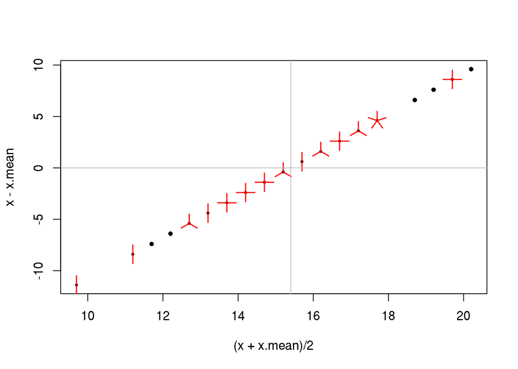

As matrix: $mean = \frac{1}{N} A^T X$

where:

$\mathbf{A^T} = \left[\begin{array} {rrr} 1 & ... & 1 \end{array}\right]$

```r
t(matrix(1, n, 1)) %*% matrix(x, n, 1) / n
```

```
##      [,1]
## [1,] 15.4
```

```r
crossprod(matrix(1, n, 1), matrix(x, n, 1)) / n # inner product
```

```
##      [,1]
## [1,] 15.4
```

```r
p <- split(x, gl(5, length(x) / 5))
(sum(sapply(p, mean)) / length(p))
```

```
## [1] 15.4
```

Other (Pythagorean) means (AM >= GM >= HM)

Geormetric (processes change multiplicatively)

```r
prod(x) ^ (1 / n)
```

```
## [1] 14.32501
```

```r
exp(mean(log(x)))
```

```
## [1] 14.32501
```

Harmonic mean (x > 0) (average of rates (reciprocals))

```r
1 / mean (1 / x)
```

```
## [1] 12.96153
```

Weighted mean

```r
w <- (n:1) / sum(n:1) # 1
crossprod(w, x) / sum(w)
```

```
##          [,1]
## [1,] 12.48078
```

```r
weighted.mean(x, w)
```

```
## [1] 12.48078
```

```r
weighted.mean(x, rep(1/n, n) )
```

```
## [1] 15.4
```

Generalized mean (power mean, or $k^{th}$ - moment) (p=0, geometric mean)

```r
gmean <- function(x, p, n = length(x), w = rep(1/n, n))
  as.vector(if(p == 0) prod(sapply(1:n, function(i) { x[i] ^ w[i] })) ^ (1 / sum(w))
  else (crossprod(w, x ^ p) / sum(w)) ^ (1 / p))

gmean(x, 0) #geometric mean
```

```
## [1] 14.32501
```

```r
gmean(x, 0, w = w) #weighted geometric mean
```

```
## [1] 11.55176
```

```r
gmean(x, 1) #arithmetic mean
```

```
## [1] 15.4
```

```r
gmean(x, 1, w = w) #weighted arithmetic mean
```

```
## [1] 12.48078
```

```r
gmean(x, 2) #quadratic mean (RMS - root mean square)
```

```
## [1] 16.2653
```

```r
sqrt(c(mean(x) ^ 2 + var(x), mean(x ^ 2)))
```

```
## [1] 16.28248 16.26530
```

```r
gmean(x, 3) #cubic mean
```

```
## [1] 16.98707
```

## Mode

```r
(freq <- table(x))
```

```
## x
##  4  7  8  9 10 11 12 13 14 15 16 17 18 19 20 22 23 24 25
##  2  2  1  1  3  2  4  4  4  3  2  3  4  3  5  1  1  4  1
```

```r
as.numeric(names(freq)[which.max(freq)])
```

```
## [1] 20
```

## Range

```r
c(min(x), max(x))
```

```
## [1]  4 25
```

```r
(x.range <- range(x))
```

```
## [1]  4 25
```

```r
x.range - x.mean
```

```
## [1] -11.4   9.6
```

```r
diff(x.range) / 2
```

```
## [1] 10.5
```

```r
sum(x.range) / 2 # midrange
```

```
## [1] 14.5
```

Max/min ratio (~1, no transformation needed):

```r
x.range[2] / x.range[1]
```

```
## [1] 6.25
```

## Variance (2nd moment)

Sum of squares

```r
(x.ss <- sum( (x - x.mean)^2 ))
```

```
## [1] 1370
```

Variance

```r
x.ss / (n - 1) # d.f = n - 1
```

```
## [1] 27.95918
```

```r
(x.var <- var(x))
```

```
## [1] 27.95918
```

Population variance

```r
x.ss / n
```

```
## [1] 27.4
```

```r
(x.popvar <- var(x) * (n - 1) / n)
```

```
## [1] 27.4
```

As matrix: $variance = \frac{1}{N} r^T r$ where: $r = X - mean(X)$ (also $r^T r$ is squared length of r)

```r
r <- x - mean(x)
crossprod(r, r) / n
```

```
##      [,1]
## [1,] 27.4
```

## Standard Deviation

```r
sqrt(x.var)
```

```
## [1] 5.287644
```

```r
(x.sd <- sd(x))
```

```
## [1] 5.287644
```

Population standard deviation

```r
(x.popsd <- sqrt(x.popvar))
```

```
## [1] 5.234501
```

```r
mean(replicate(10, sd(sample(x, 30))))
```

```
## [1] 5.337444
```

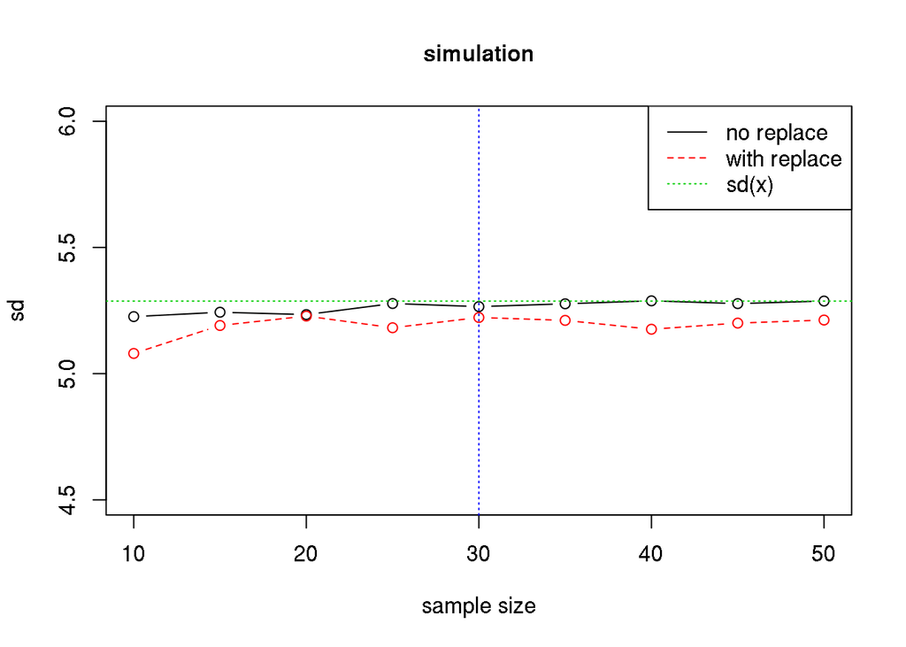

```r
# coefficient of variation
(x.sd / x.mean) * 100 # percent
```

```
## [1] 34.33535
```

## Quantiles

```r
quantile(x)
```

```
##   0%  25%  50%  75% 100%
##    4   12   15   19   25
```

```r
#median
sort(x)[n / 2] # n even
```

```
## [1] 15
```

```r
x.sorted <- sort(x)
mean(x.sorted[floor(n / 2)], x.sorted[ceiling(n / 2)]) # any n
```

```
## [1] 15
```

```r
quantile(x, 0.5)
```

```
## 50%
##  15
```

```r
(x.median <- median(x))
```

```
## [1] 15
```

```r
x.Q1 <- quantile(x)[[2]]
x.Q3 <- quantile(x)[[4]]
(x.iqr <- x.Q3 - x.Q1)
```

```
## [1] 7
```

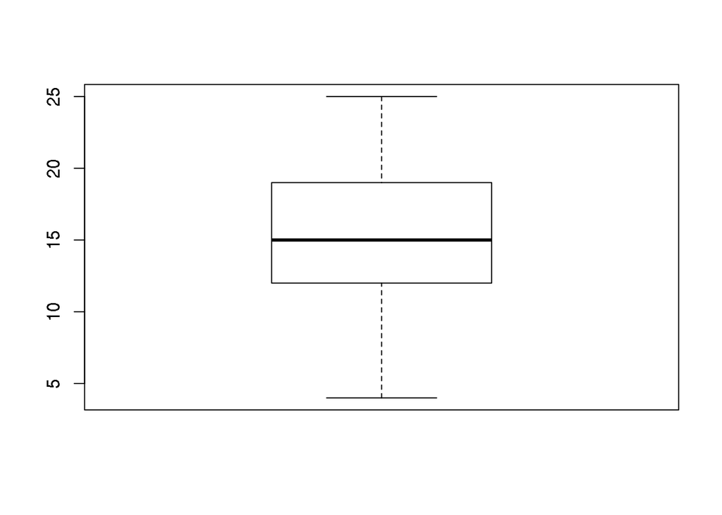

Median absolute deviation

```r
1.4826 * median(abs(x - x.median))
```

```
## [1] 5.9304
```

```r
(x.mad <- mad(x))
```

```
## [1] 5.9304
```

```r
abs(c(x.mean - x.median, x.sd - x.mad))
```

```
## [1] 0.4000000 0.6427556
```

Outliers

```r
c( x[x < (x.Q1 - 1.5 * x.iqr)], x[x > (x.Q3 + 1.5 * x.iqr)] )
```

```
## numeric(0)
```

```r
boxplot.stats(x)$out
```

```
## numeric(0)
```

```r
#car::outlier.test(x)
```

## Skew (3rd moment)

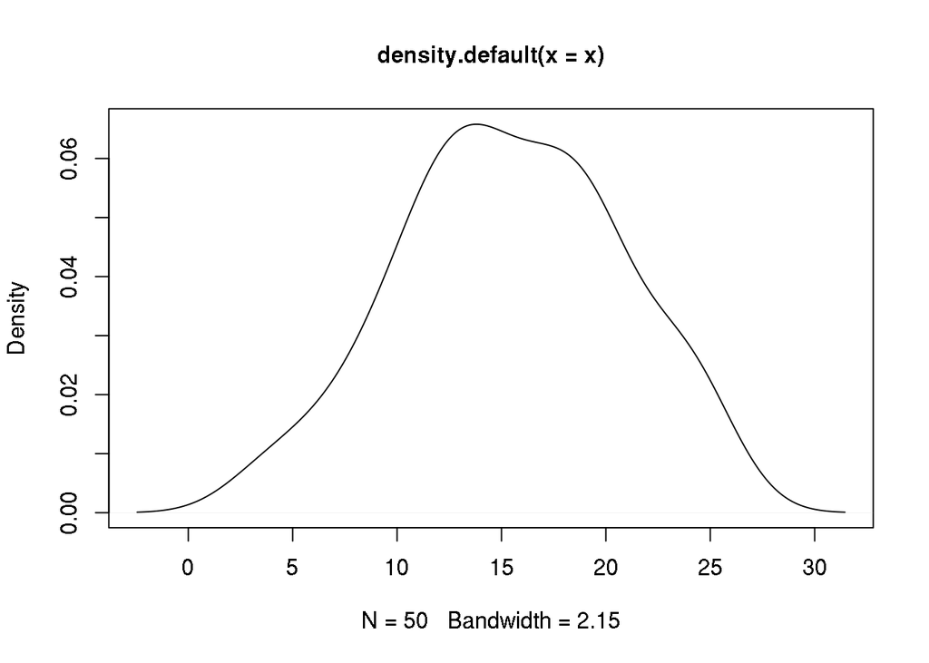

```r
plot(density(x))
```

Negative skew (longer left tail)

```r
m3 <- sum((x - mean(x))^3) / length(x)
s3 <- sqrt(var(x)) ^ 3
(x.skew <- m3 / s3)
```

```
## [1] -0.1105533
```

Significance (normal > 0.05) (see t-test)

```r
x.skew.se <- sqrt(6 / n)
x.skew / x.skew.se
```

```
## [1] -0.3191398
```

```r
1 - pt(x.skew / x.skew.se, n - 2)
```

```
## [1] 0.6244974
```

## Kurtosis (4th moment)

```r
m4 <- sum((x - mean(x))^4) / length(x)
s4 <- var(x) ^ 2
(x.kurtosis <- m4 / s4 - 3)
```

```
## [1] -0.6730924
```

```r
xx <- rnorm(50, mean=mean(x), sd=sd(x))
m4 <- sum((xx - mean(xx))^4) / length(xx)
s4 <- var(xx) ^ 2
m4 / s4 - 3 # 0
```

```
## [1] -0.6175409
```

Significance (normal > 0.05) (see t-test)

```r
x.kurtosis.se <- sqrt(24 / n)
x.kurtosis / x.kurtosis.se
```

```
## [1] -0.9715252
```

```r
1 - pt(x.kurtosis / x.kurtosis.se, n - 2)
```

```
## [1] 0.8319214
```

## Standardization (z-score)

Tests for normal

```r
# pvalue > 0.05, normal
shapiro.test(x)
```

```
##
##  Shapiro-Wilk normality test
##
## data:  x
## W = 0.9776, p-value = 0.4576
```

```r
ks.test(unique(x), "pnorm", mean(unique(x)), sd(unique(x)))
```

```
##
##  One-sample Kolmogorov-Smirnov test
##
## data:  unique(x)
## D = 0.0806, p-value = 0.9987
## alternative hypothesis: two-sided
```

```r
ks.test(x, "pnorm", mean(x), sd(x), exact = FALSE)
```

```
##
##  One-sample Kolmogorov-Smirnov test
##
## data:  x
## D = 0.0685, p-value = 0.9729
## alternative hypothesis: two-sided
```

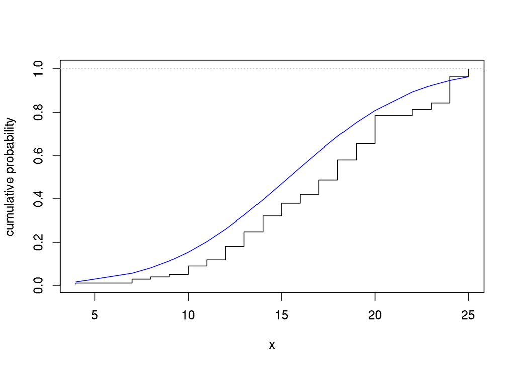

```r
#plot(ecdf(x), col="red")
plot(sort(x), cumsum(sort(x)) / sum(x), type = 's', xlab="x", ylab="cumulative probability")
lines(sort(x), pnorm(sort(x), mean=x.mean, sd=x.sd), type="l", col="blue")
abline(h=1, col="gray", lty=3)
```

Standardization

```r
x.z <- (x - x.mean) / x.sd
head(x.z)
```

```
## [1] -2.155969 -2.155969 -1.588609 -1.588609 -1.399489 -1.210369
```

```r
mean(x.z)
```

```
## [1] -5.42795e-17
```

```r
sd(x.z)
```

```
## [1] 1
```

```r
head(scale(x))
```

```
##           [,1]
## [1,] -2.155969
## [2,] -2.155969
## [3,] -1.588609
## [4,] -1.588609
## [5,] -1.399489
## [6,] -1.210369
```

Assuming normal distribution

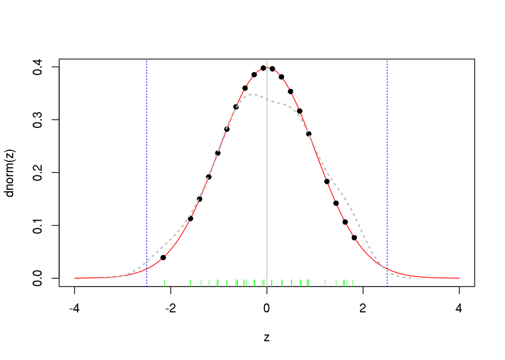

```r
temp.xx <- seq(-4,4, length.out=100)
temp.xx <- pretty(c(-4, 4), 100)
plot(temp.xx, dnorm(temp.xx), type="l", xlab="z", ylab="dnorm(z)", col="red")
rug(jitter(x.z), col="green")
abline(v=0, col="gray")
abline(v=c(-2.5, 2.5), col="blue", lty=3)
points(x.z, dnorm(x.z), pch=16)
lines(density(x.z), col="gray", lwd=2, lty=3)
```

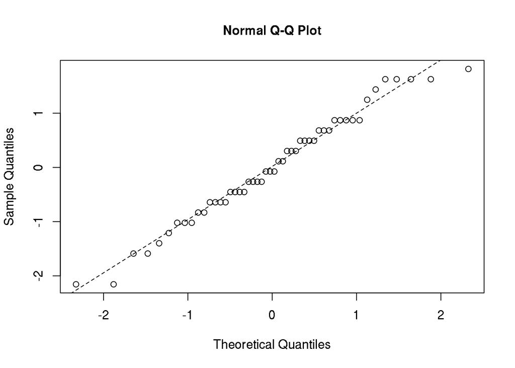

```r
qqnorm(x.z)
qqline(x.z, lty=2)
```

Probability of speed bigger than selected

```r
(z1 <- sample(x.z, 1))
```

```
## [1] 0.8699526
```

```r
which(x.z == z1)
```

```
## [1] 39 40 41 42 43
```

```r
x[x.z == z1]
```

```
## [1] 20 20 20 20 20
```

```r
1 - pnorm(z1)
```

```
## [1] 0.1921632
```

Check

```r
abs(qnorm(1 - pnorm(z1)))
```

```
## [1] 0.8699526
```

```r
pnorm(z1)
```

```
## [1] 0.8078368
```

```r
integrate(dnorm, -Inf, z1)
```

```
## 0.8078368 with absolute error < 6.5e-08
```

```r
1 - pnorm(z1)
```

```
## [1] 0.1921632
```

```r
integrate(dnorm, z1, Inf)
```

```
## 0.1921631 with absolute error < 2.2e-05
```

Probability of speed between z1, z2

```r
(z12 <- sort(sample(x.z, 2)))
```

```
## [1] -1.0212487  0.6808325
```

```r
pnorm(z12[2]) - pnorm(z12[1])
```

```
## [1] 0.5984429
```

```r
integrate(dnorm, z12[1], z12[2])
```

```
## 0.5984429 with absolute error < 6.6e-15
```

Bivariate density plot

```r
suppressWarnings(suppressMessages(sm::sm.density(cars)))
```

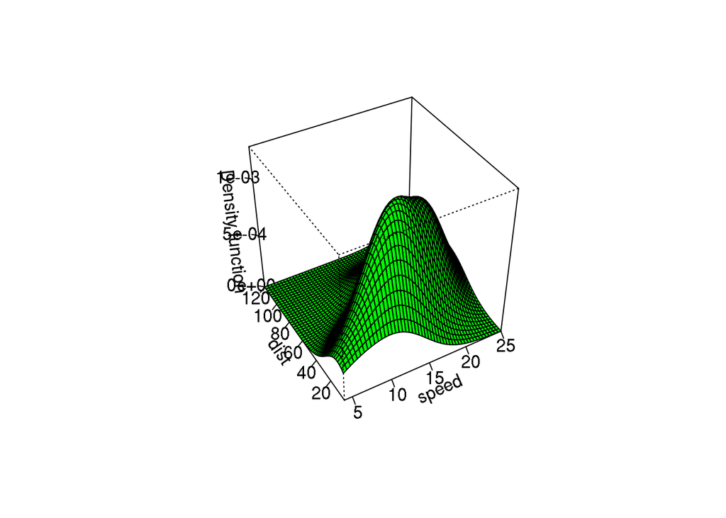

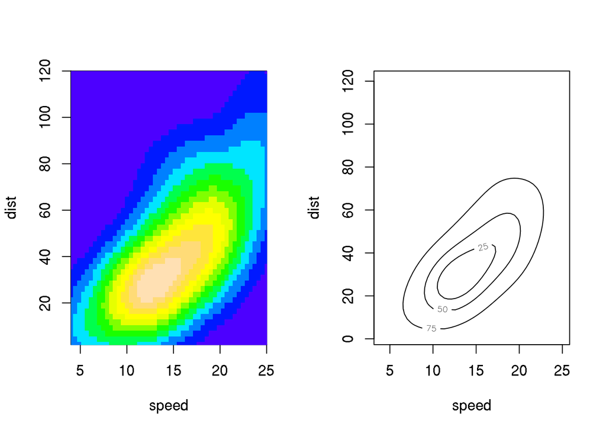

```r
op <- par(mfrow = c(1, 2))
suppressWarnings(suppressMessages(sm::sm.density(cars, display="image")))
suppressWarnings(suppressMessages(sm::sm.density(cars, display="slice")))
```

```r
par(op)
```

## Central Tendency (CLT)

$P( \frac{S_n / n - \mu}{\sigma / \sqrt{n}} \le t) \to P(Z \le t), n \to \infty, Z \sim Norm(0,1)$

Applies to mean

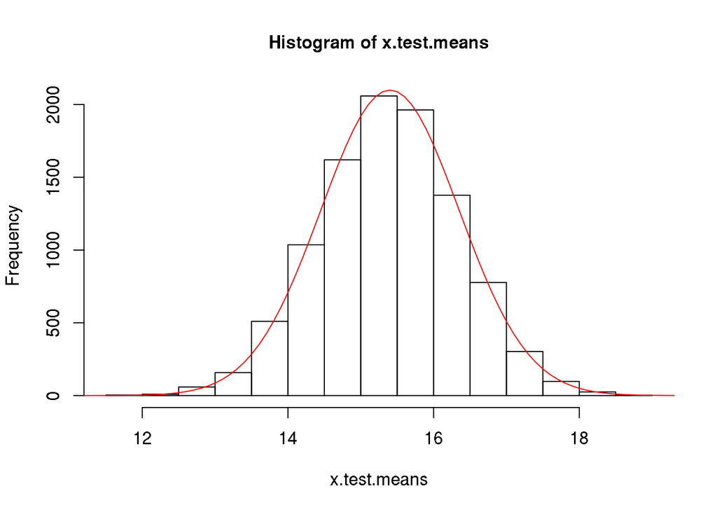

```r
set.seed(1)
x.test.means <- replicate(10000, mean(sample(x, 30, replace = TRUE)))
h <- hist(x.test.means)
xx <- seq(0, 20, 0.1)
lines(xx, dnorm(xx, mean=mean(x.test.means), sd=sd(x.test.means)) * length(x.test.means) * diff(h$mids[1:2]), col="red")
```

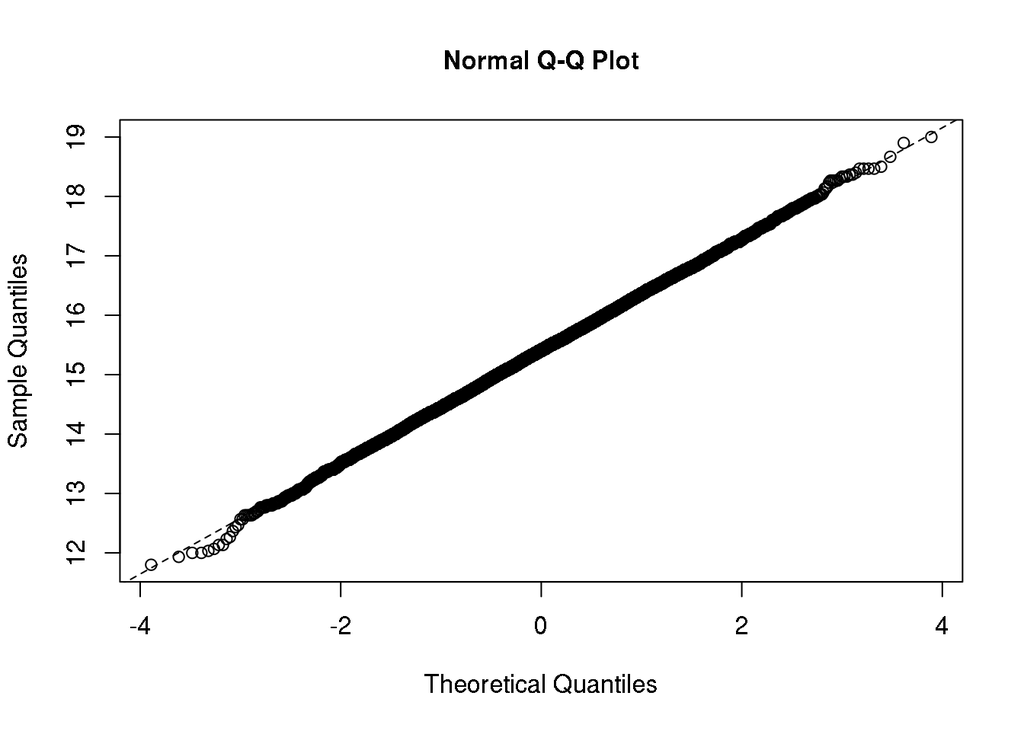

```r
qqnorm(x.test.means)
qqline(x.test.means, lty=2)
```

```r
quantile(x.test.means, c(0.025, 0.975)) # 95%
```

```
##     2.5%    97.5%
## 13.53333 17.23333
```

Variance

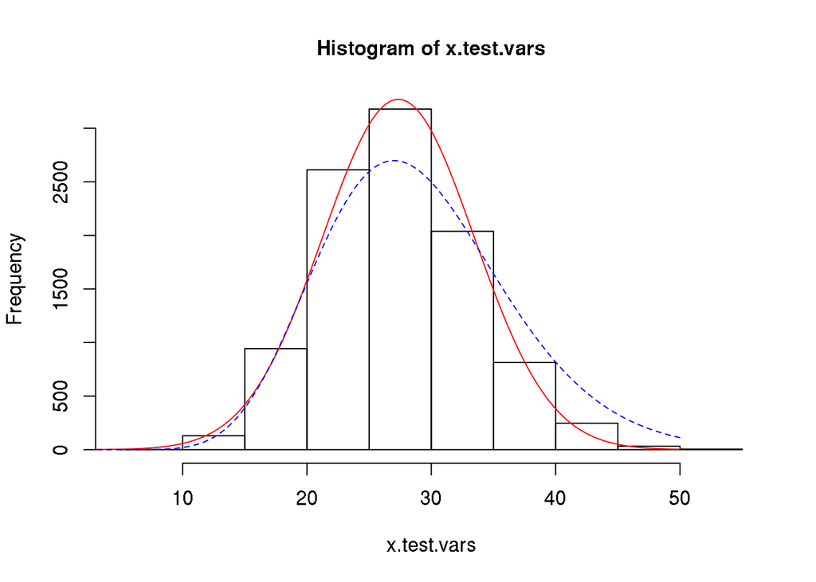

```r
x.test.vars <- replicate(10000, var(sample(x, 30, replace = TRUE)))
h <- hist(x.test.vars)
xx <- seq(0, 50, 0.1)
xx.scale <- length(x.test.vars) * diff(h$mids[1:2])
lines(xx, dnorm(xx, mean=mean(x.test.vars), sd=sd(x.test.vars)) * xx.scale, col="red" )
lines(xx, dchisq(xx, 29)  * xx.scale, col="blue", lty=2)
```

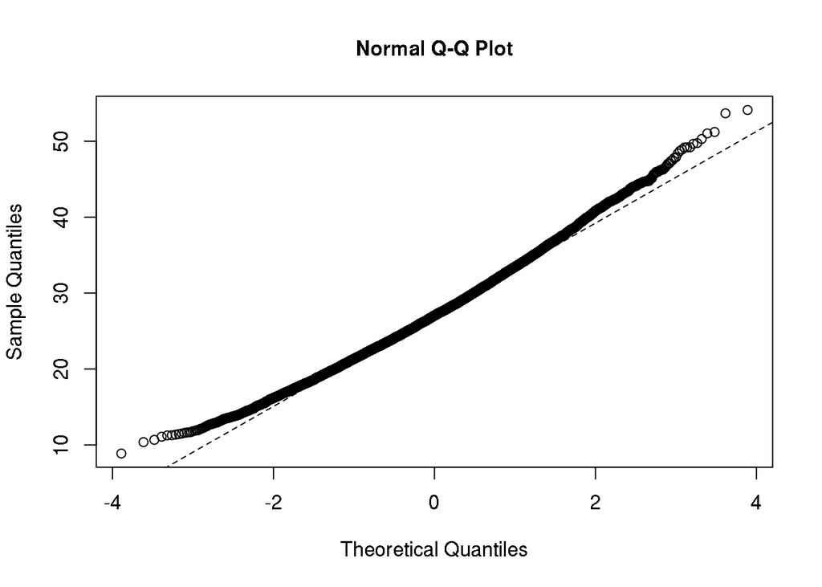

```r
qqnorm(x.test.vars)
qqline(x.test.vars, lty=2)
```

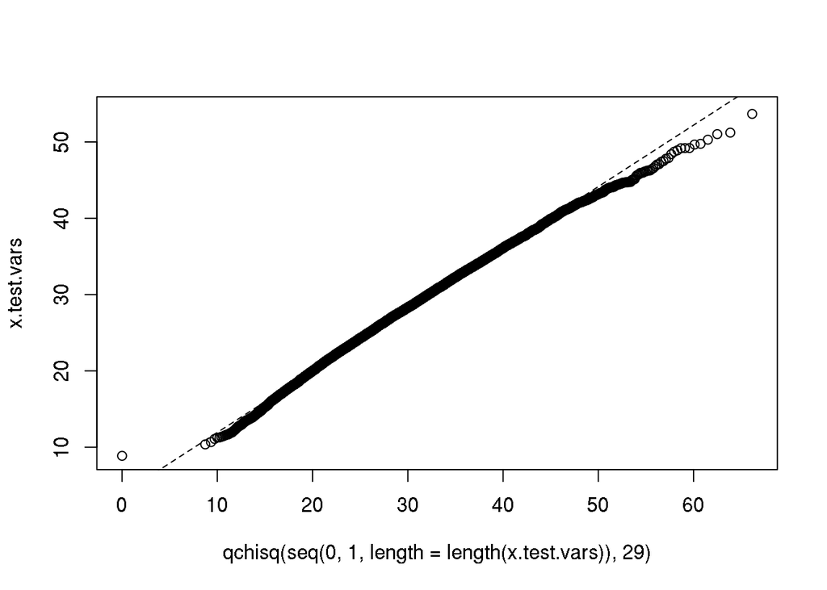

```r
qqplot(qchisq(seq(0, 1, length=length(x.test.vars)), 29), x.test.vars)
qqline(x.test.vars, distribution = function(p) qchisq(p, 29), prob = c(0.1, 0.9), lty=2)
```

```r
quantile(x.test.vars, c(0.025, 0.975)) # 95%
```

```
##     2.5%    97.5%
## 16.37802 40.46101
```

Median

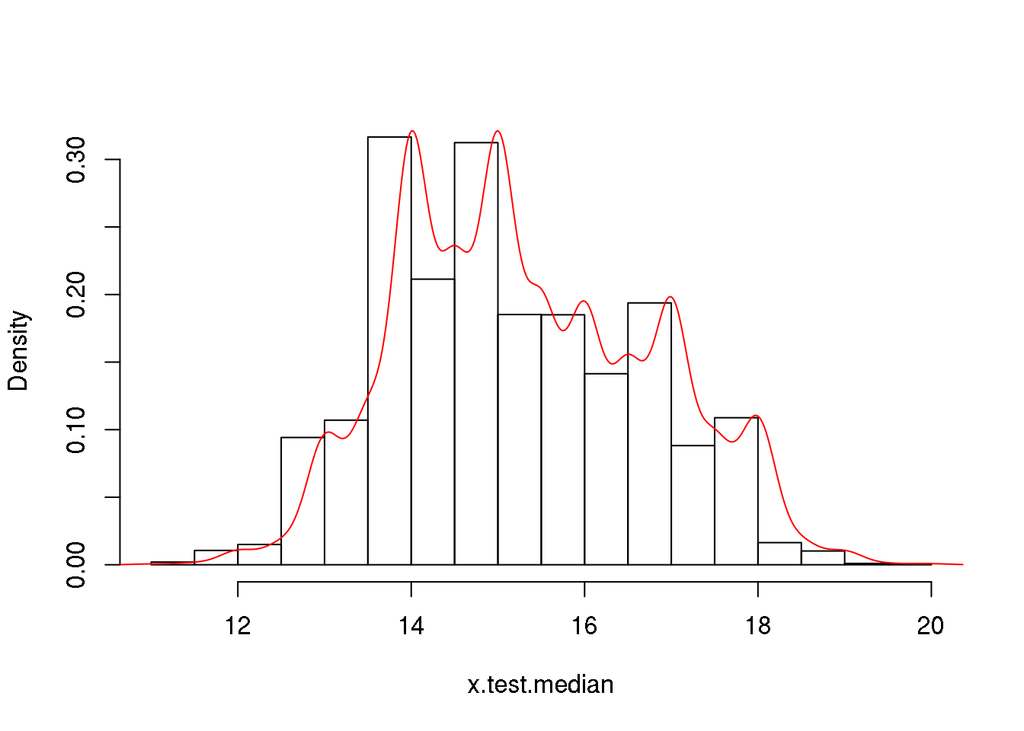

```r
x.test.median <- replicate(10000, median(sample(x, 30, replace = TRUE)))
h <- hist(x.test.median, freq = FALSE, main = "")
xx <- density(x.test.median)
lines(xx$x, xx$y, col="red")
```

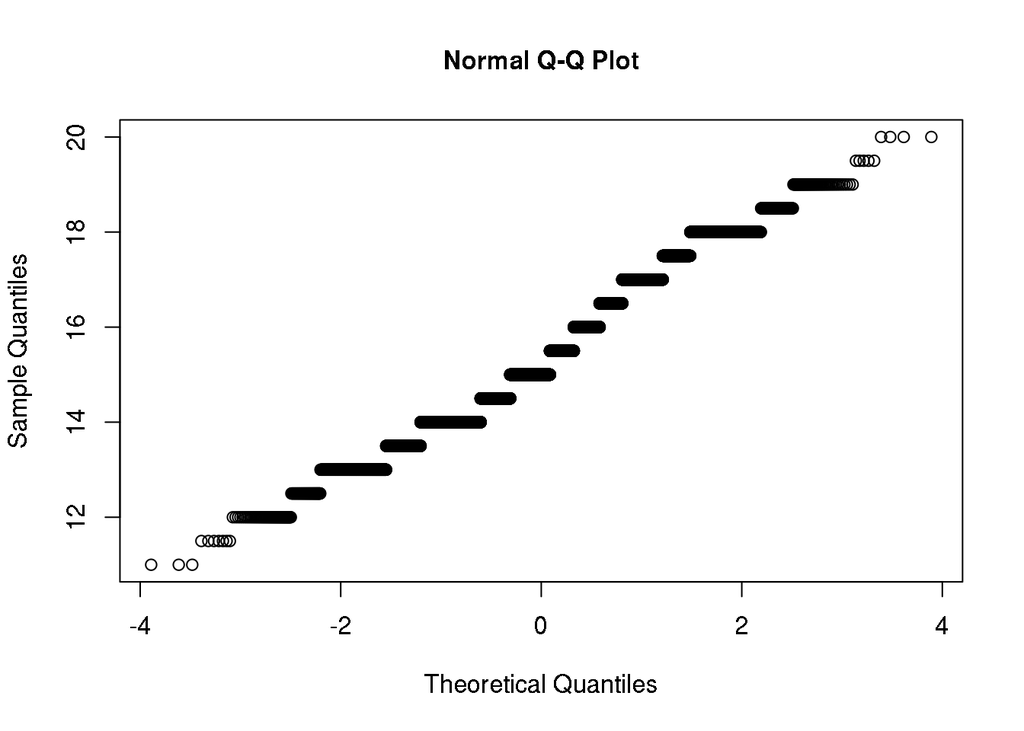

```r
qqnorm(x.test.median)
```

```r
quantile(x.test.median, c(0.025, 0.5, 0.975)) # 95%
```

```
##  2.5%   50% 97.5%
##    13    15    18
```

## Standart Error of the Mean (SEM)

x.mean +/- sem

```r
(x.mean.sem <- sqrt(x.var / n))
```

```
## [1] 0.7477858
```

Z-Statistic

```r
x1 <- sample(x, 30)
x1.mean <- mean(x1) # sample mean
(x1.mean.sem <- sqrt(x.var / 30)) # sd(x) / sqrt(30)
```

```
## [1] 0.9653874
```

```r
(Z <- (x1.mean - x.mean) / x1.mean.sem)
```

```
## [1] 1.035854
```

```r
1 - pnorm(Z) # p-value
```

```
## [1] 0.1501352
```

```r
alpha <- 0.05 # 1 - 0.95
(p <- 1 - (alpha / 2))
```

```
## [1] 0.975
```

```r
qnorm(p)
```

```
## [1] 1.959964
```

```r
# z-stat confidence interval
c(x1.mean - qnorm(p) * x1.mean.sem, x1.mean, x1.mean + qnorm(p) * x1.mean.sem)
```

```
## [1] 14.50788 16.40000 18.29212
```

## Confidence Interval

x.mean +/- ci (95% CI, n = 50)

```r
alpha <- 0.05 # 1 - 0.95
(p <- 1 - (alpha / 2))
```

```
## [1] 0.975
```

```r
qt(p, n - 1) * x.mean.sem
```

```
## [1] 1.502732
```

```r
qnorm(p) * x.mean.sem
```

```
## [1] 1.465633
```

```r
(qnorm(p))
```

```
## [1] 1.959964
```

```r
c(x.mean - qt(p, n - 1) * x.mean.sem, x.mean, x.mean + qt(p, n - 1) * x.mean.sem)
```

```
## [1] 13.89727 15.40000 16.90273
```

Variance

```r
c((n - 1) * x.var / qchisq(0.975, n - 1), x.var, (n - 1) * x.var / qchisq(0.025, n - 1))
```

```
## [1] 19.50944 27.95918 43.41637
```

## Variance Test (f-test)

```r
alpha <- 0.05 # 1 - 0.95
p <- 1 - (alpha / 2)

sn <- 30
df.sn <- sn - 1
x.s1 <- sample(x, sn)
x.s2 <- sample(x, sn)

(x.s1.var <- var(x.s1))
```

```
## [1] 23.04483
```

```r
(x.s2.var <- var(x.s2))
```

```
## [1] 26.56207
```

```r
temp <- c(x.s1.var, x.s2.var)
(f.ratio <- max(temp) / min(temp))
```

```
## [1] 1.152626
```

```r
(p.value <- 2 * (1 - pf(f.ratio, df.sn, df.sn))) # two tailed
```

```
## [1] 0.7046715
```

```r
var.test(x.s1, x.s2)
```

```
##
##  F test to compare two variances
##
## data:  x.s1 and x.s2
## F = 0.8676, num df = 29, denom df = 29, p-value = 0.7047
## alternative hypothesis: true ratio of variances is not equal to 1
## 95 percent confidence interval:
##  0.4129395 1.8227905
## sample estimates:
## ratio of variances
##          0.8675841
```

More than two groups:

```r
x.s3 <- sample(x, sn)

bartlett.test(c(x.s1, x.s2, x.s3) ~ gl(3, sn))
```

```
##
##  Bartlett test of homogeneity of variances
##
## data:  c(x.s1, x.s2, x.s3) by gl(3, sn)
## Bartlett's K-squared = 0.1472, df = 2, p-value = 0.929
```

Robust variance test:

```r
fligner.test(c(x.s1, x.s2) ~ gl(2, sn))
```

```
##
##  Fligner-Killeen test of homogeneity of variances
##
## data:  c(x.s1, x.s2) by gl(2, sn)
## Fligner-Killeen:med chi-squared = 0.1761, df = 1, p-value = 0.6748
```

## Mean Test (t-test)

z = tstat = (m1 - m2) / sem (under CLT this in nomral mean=0, sd=1)

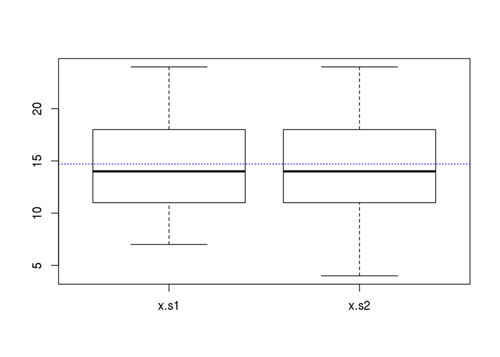

```r
boxplot(c(x.s1, x.s2) ~ rep(c("x.s1", "x.s2"), each=sn))
abline(h=mean(x.s1), col="red", lty=3)
abline(h=mean(x.s2), col="blue", lty=3)
```

Two-sample t-test:

```r
(tstat <- (mean(x.s1) - mean(x.s2)) / sqrt(var(x.s1) / sn + var(x.s2) / sn)) # assuming independence
```

```
## [1] 0
```

```r
(p.value.z <- 1 - pnorm(abs(tstat)) + pnorm(-abs(tstat))) # 2 * pnorm(-abs(tstat))
```

```
## [1] 1
```

```r
(p.value.t <- 1 - pt(abs(tstat), sn - 2) + pt(-abs(tstat), sn - 2))
```

```
## [1] 1
```

```r
t.test(x.s1, x.s2, var.equal = TRUE) # add paired=TRUE for paired
```

```
##
##  Two Sample t-test
##
## data:  x.s1 and x.s2
## t = 0, df = 58, p-value = 1
## alternative hypothesis: true difference in means is not equal to 0
## 95 percent confidence interval:
##  -2.574028  2.574028
## sample estimates:
## mean of x mean of y
##      14.7      14.7
```

```r
t.test(x.s1, x.s2, var.equal = FALSE) # better, default
```

```
##
##  Welch Two Sample t-test
##
## data:  x.s1 and x.s2
## t = 0, df = 57.71, p-value = 1
## alternative hypothesis: true difference in means is not equal to 0
## 95 percent confidence interval:
##  -2.574303  2.574303
## sample estimates:
## mean of x mean of y
##      14.7      14.7
```

Robust mean tests

```r
wilcox.test(x.s1, x.s2)
```

```
##
##  Wilcoxon rank sum test with continuity correction
##
## data:  x.s1 and x.s2
## W = 442, p-value = 0.9114
## alternative hypothesis: true location shift is not equal to 0
```

Binomial sign test

```r
d <- x.s1 - x.s2
binom.test(sum(d > 0), length(d)) # p = 0.5
```

```
##
##  Exact binomial test
##
## data:  sum(d > 0) and length(d)
## number of successes = 13, number of trials = 30, p-value = 0.5847
## alternative hypothesis: true probability of success is not equal to 0.5
## 95 percent confidence interval:
##  0.2546075 0.6257265
## sample estimates:
## probability of success
##              0.4333333
```

One sample t-test

```r
t.test(x.s1, mu=x.mean)
```

```
##
##  One Sample t-test
##
## data:  x.s1
## t = -0.7987, df = 29, p-value = 0.431
## alternative hypothesis: true mean is not equal to 15.4
## 95 percent confidence interval:
##  12.90746 16.49254
## sample estimates:
## mean of x
##      14.7
```

```r
wilcox.test(x.s1, mu=x.mean)
```

```
##
##  Wilcoxon signed rank test with continuity correction
##
## data:  x.s1
## V = 194, p-value = 0.4341
## alternative hypothesis: true location is not equal to 15.4
```

## Analysis of Variance (ANOVA)

```r
rbind(tapply(c(x.s1, x.s2, x.s3), gl(3, sn), mean),
tapply(c(x.s1, x.s2, x.s3), gl(3, sn), sd),
tapply(c(x.s1, x.s2, x.s3), gl(3, sn), length))
```

```
##              1        2         3
## [1,] 14.700000 14.70000 15.200000
## [2,]  4.800503  5.15384  5.026825
## [3,] 30.000000 30.00000 30.000000
```

Manual (one-way) ANOVA for x.s1, x.s2

```r
k <- 2 # groups
N <- length(x.s1) + length(x.s2) # total
Y <- c(x.s1, x.s2)
x.s1.mean <- mean(x.s1)
x.s2.mean <- mean(x.s2)
ssw1 <- sum((x.s1 - x.s1.mean) ^ 2)
ssw2 <- sum((x.s2 - x.s2.mean) ^ 2)
(ssw <- ssw1 + ssw2) # ss of differenced within groups, aka: sse (error, residual variation)
```

```
## [1] 1438.6
```

```r
x.pool.mean <- mean(Y)
ssb1 <- sum((x.s1.mean - x.pool.mean) ^ 2)
ssb2 <- sum((x.s2.mean - x.pool.mean) ^ 2)
(ssb <- ssb1 + ssb2) # ss of differences between groups, ssa (treatment, model variation)
```

```
## [1] 0
```

```r
(sst <- ssb + ssw) # aka: ssy (total)
```

```
## [1] 1438.6
```

```r
sum((Y - x.pool.mean)^ 2) # sst: sum( (y - mean(y)) ^ 2 )
```

```
## [1] 1438.6
```

```r
# normalized ss (mean sum of squares)
(msw <- ssw / (N - k)) # df
```

```
## [1] 24.80345
```

```r
(msb <- ssb / (k - 1)) # df
```

```
## [1] 0
```

```r
# msb estimate of pooled variance (!= if group mean difference effect)
# msw estimate of pooled variance from group variances
# variance f-test
(F <- msb / msw)
```

```
## [1] 0
```

```r
(PF <- 1 - pf(F, k - 1, N - k)) # Pr(>F), one-sided variance f-test
```

```
## [1] 1
```

```r
a <- rbind(c(k - 1, ssb, msb, F, PF),
      c(N - k, ssw, msw, 0, 0),
      c(N - 1, sst, 0, 0, 0)) # 0s added to get same length
rownames(a) <- c("model (b)", "error (w)", "total (y)")
colnames(a) <- c("df", "ss", "mss", "f", "pf")
a
```

```
##           df     ss      mss f pf
## model (b)  1    0.0  0.00000 0  1
## error (w) 58 1438.6 24.80345 0  0
## total (y) 59 1438.6  0.00000 0  0
```

```r
var(Y) # mss
```

```
## [1] 24.38305
```

### One-way ANOVA

```r
library(car)
leveneTest(c(x.s1, x.s2) ~ gl(2, sn)) # homogenious group variance test
```

```
## Levene's Test for Homogeneity of Variance (center = median)
##       Df F value Pr(>F)
## group  1  0.1909 0.6638
##       58
```

```r
#Difference between groups (gl), and difference within groups (Residuals)
anova(lm(c(x.s1, x.s2) ~ gl(2, sn)))
```

```
## Analysis of Variance Table
##
## Response: c(x.s1, x.s2)
##           Df Sum Sq Mean Sq F value Pr(>F)
## gl(2, sn)  1    0.0   0.000       0      1
## Residuals 58 1438.6  24.803
```

```r
anova(lm(c(x.s1, x.s2, x.s3) ~ gl(3, sn)))
```

```
## Analysis of Variance Table
##
## Response: c(x.s1, x.s2, x.s3)
##           Df Sum Sq Mean Sq F value Pr(>F)
## gl(3, sn)  2    5.0   2.500  0.1002 0.9048
## Residuals 87 2171.4  24.959
```

Two-group comparisons (p-value table)

```r
pairwise.t.test(c(x.s1, x.s2, x.s3), gl(3, sn), p.adj="bonferroni")
```

```
##
##  Pairwise comparisons using t tests with pooled SD
##
## data:  c(x.s1, x.s2, x.s3) and gl(3, sn)
##
##   1 2
## 2 1 -
## 3 1 1
##
## P value adjustment method: bonferroni
```

```r
# not using same varince
pairwise.t.test(c(x.s1, x.s2, x.s3), gl(3, sn), pool.sd=FALSE)
```

```
##
##  Pairwise comparisons using t tests with non-pooled SD
##
## data:  c(x.s1, x.s2, x.s3) and gl(3, sn)
##
##   1 2
## 2 1 -
## 3 1 1
##
## P value adjustment method: holm
```

Non equal variance assumption

```r
oneway.test(c(x.s1, x.s2, x.s3) ~ gl(3, sn))
```

```
##
##  One-way analysis of means (not assuming equal variances)
##
## data:  c(x.s1, x.s2, x.s3) and gl(3, sn)
## F = 0.0986, num df = 2.000, denom df = 57.949, p-value = 0.9063
```

Robust

```r
kruskal.test(c(x.s1, x.s2, x.s3) ~ gl(3, sn))
```

```
##
##  Kruskal-Wallis rank sum test
##
## data:  c(x.s1, x.s2, x.s3) by gl(3, sn)
## Kruskal-Wallis chi-squared = 0.2532, df = 2, p-value = 0.8811
```

```r
# for two way anova see friedman.test
```

## Power

TypeII: P(acceptH0 | H0.False) = $\beta$, TypeI: P(rejectH0 | H0.True) = $\alpha$, Power = 1 - $\beta$ = P(rejectH0 | H0.False)

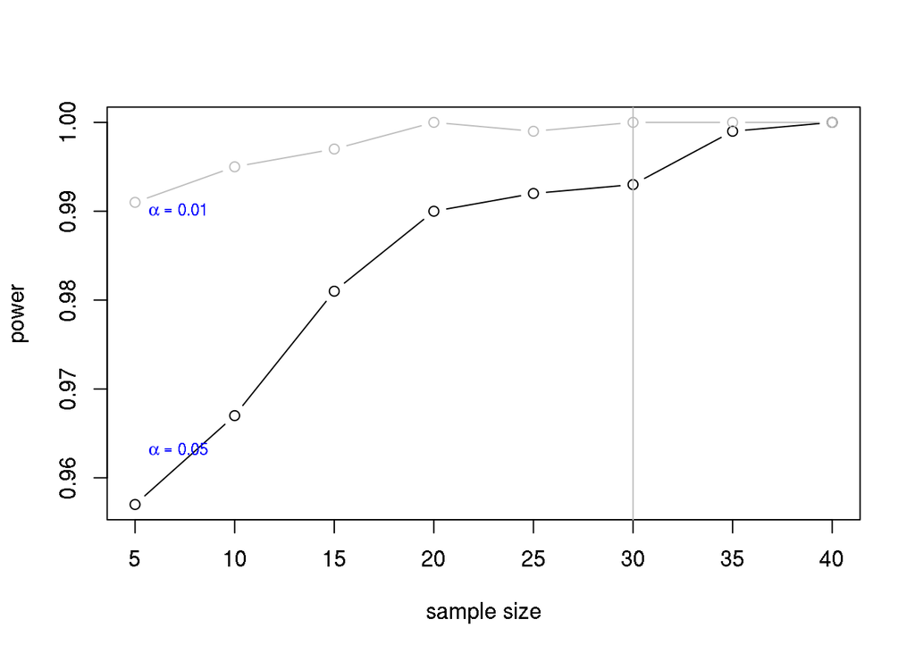

```r
reject <- function(sn, alpha) {
  x.s1 <- sample(x, sn)
  x.s2 <- sample(x, sn)
  p.value <- t.test(x.s1, x.s2, var.equal = TRUE)$p.value
  !(p.value < alpha) # reject null wrong
}

reject1000 <- function(sn, alpha) {
  mean(replicate(1000, reject(sn, alpha))) # prob. of rejecting null
}

power <- seq(5, 40, 5)
plot(power, sapply(power, reject1000, 0.05), type="b", xlab="sample size", ylab="power")
lines(power, sapply(power, reject1000, 0.01), type="b", col="gray")
abline(v=30, col="gray")
text(c(5, 5), c(0.963, 0.99),
     c(expression(paste(alpha," = 0.05")),
       expression(paste(alpha," = 0.01"))),
     cex = .8, col="blue", pos=4)
```

Parametric simulation

```r
data <- rnorm(1000, mean=0, sd=1) # rnorm(100, mean=x.mean, sd=x.sd)
data <- (data - mean(data)) / sd(data)
data <- x.mean + data * x.sd

mean(data)
```

```
## [1] 15.4
```

```r
sd(data)
```

```
## [1] 5.287644
```

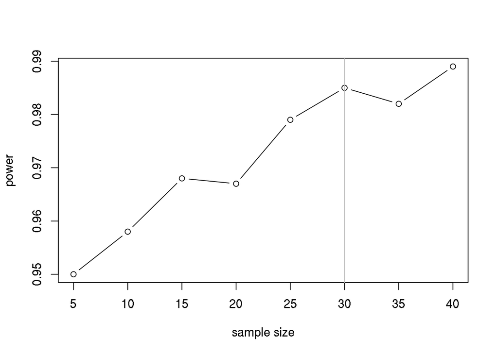

```r
reject <- function(sn, alpha) {
  x.s1 <- sample(x, sn)
  x.s2 <- sample(data, sn)
  p.value <- t.test(x.s1, x.s2, var.equal = TRUE)$p.value
  !(p.value < alpha) # reject null wrong
}

reject1000 <- function(sn, alpha) {
  mean(replicate(1000, reject(sn, alpha)))
}

power <- seq(5, 40, 5)
plot(power, sapply(power, reject1000, 0.05), type="b", xlab="sample size", ylab="power")
abline(v=30, col="gray")
```

```r
power.t.test(delta=5, sd=x.sd, power=0.8) # delta = mean(x1) - mean(x2)
```

```
##
##      Two-sample t test power calculation
##
##               n = 18.56699
##           delta = 5
##              sd = 5.287644
##       sig.level = 0.05
##           power = 0.8
##     alternative = two.sided
##
## NOTE: n is number in *each* group
```

Binomial - probability of having at least one fast car in the sample size

```r
(prob.fast.car <- sum(x > 1.2 * x.mean) / n)
```

```
## [1] 0.3
```

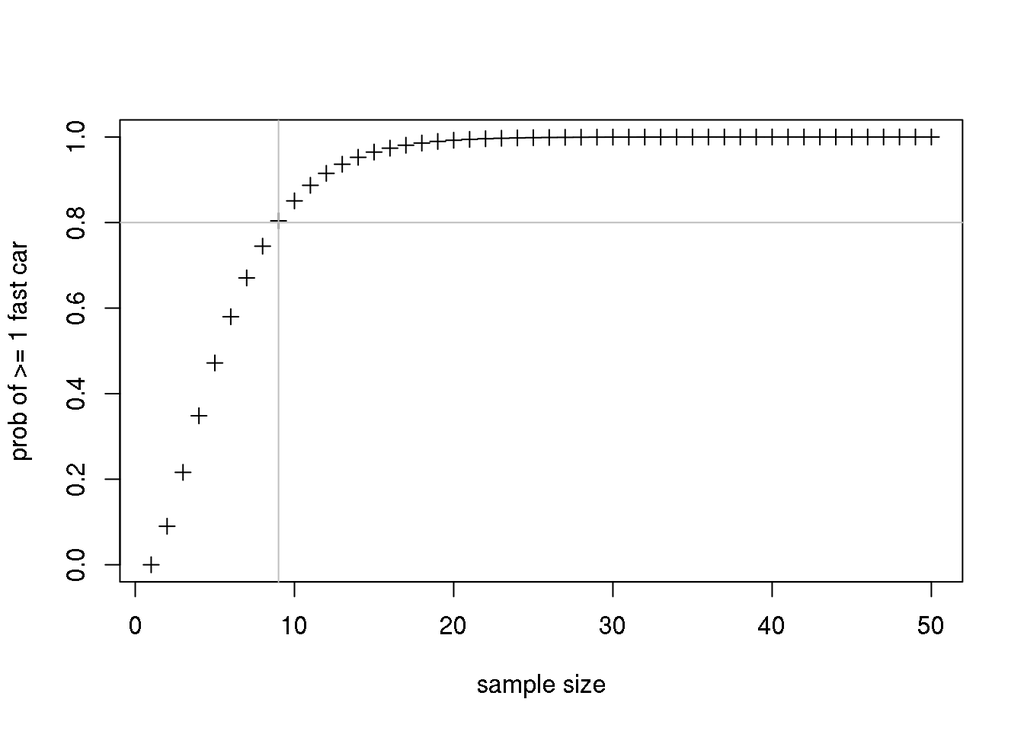

```r
fb <- function(s) { 1 - pbinom(1, s, prob.fast.car) }
plot(1:n, sapply(1:n, fb),
     xlab="sample size", ylab="prob of >= 1 fast car", pch=3)
abline(h=0.8, v=9, col="gray")
```

```r
# with 95% confidence for a sample size of 9 we get [a,b] cars (mean = 9 * prob.fast.car)
c(qbinom(.025, 9, prob.fast.car), qbinom(.975, 9, prob.fast.car))
```

```
## [1] 0 6
```

Verify

```r
sum(replicate(100, sum(sample(x, 9) > 1.2 * x.mean))) / 100 # 100 experiments
```

```
## [1] 2.64
```

Approximation

```r
approx <- function(k1, k2, N, p) {
  a <- (k1 - N * p) / sqrt(N * p * (1 - p))
  b <- (k2 - N * p) / sqrt(N * p * (1 - p))
  pnorm(b) - pnorm(a)
}
dbinom(1, 30, 0.3)
```

```
## [1] 0.0002897915
```

```r
approx(1 - 0.5, 1 + 0.5, 30, 0.3) # normal
```

```
## [1] 0.001049743
```

```r
dpois(2, 30 * 0.3) #poisson
```

```
## [1] 0.004998097
```

## Association Test

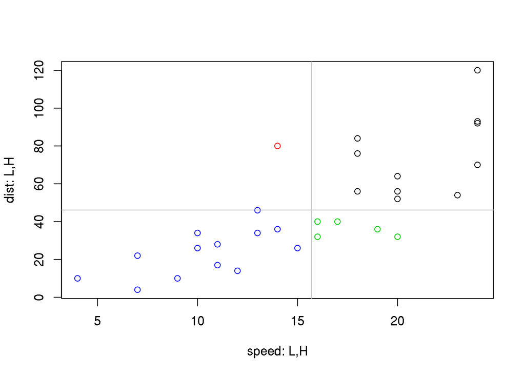

```r
gcars <- cars[sample(1:n, 30), ]
#dist,speed
gcars[gcars$dist < mean(gcars$dist) & gcars$speed < mean(gcars$speed), "group"] = "LL"
gcars[gcars$dist < mean(gcars$dist) & gcars$speed >= mean(gcars$speed), "group"] = "LH"
gcars[gcars$dist >= mean(gcars$dist) & gcars$speed < mean(gcars$speed), "group"] = "HL"
gcars[gcars$dist >= mean(gcars$dist) & gcars$speed >= mean(gcars$speed), "group"] = "HH"

plot(gcars$speed, gcars$dist, col=as.factor(gcars$group), ylab="dist: L,H", xlab="speed: L,H")
abline(h=mean(gcars$dist), v=mean(gcars$speed), col="gray")
```

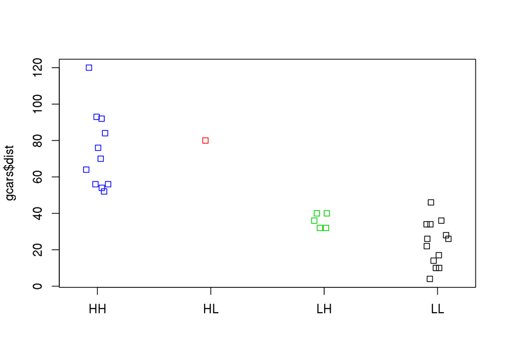

```r
stripchart(gcars$dist ~ gcars$group, data=gcars, vertical=TRUE, method="jitter", col=c(4,2,3,1))
```

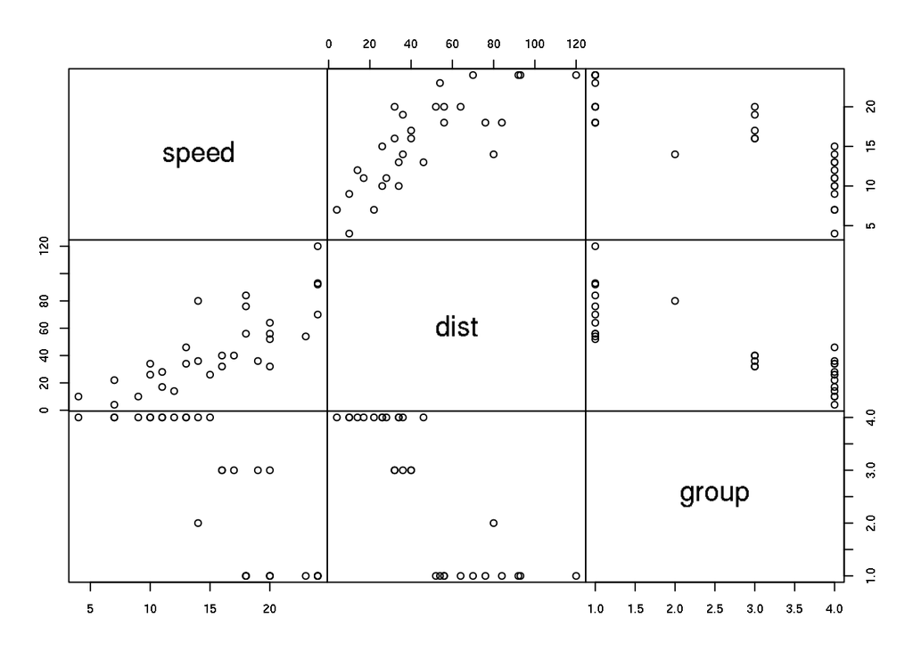

```r
gcars$group <- as.factor(gcars$group)
pairs(gcars, gap=0)
```

```r
m <- matrix(unlist(rev(table(gcars$group))), 2, 2, byrow=TRUE)
colnames(m) <- c("speed.low", "speed.high")
rownames(m) <- c("dist.low", "dist.high")
# m contingency table r x c
(ma <- addmargins(m)) # rowSums(m), colSums(m), sum(m)
```

```
##           speed.low speed.high Sum
## dist.low         13          5  18
## dist.high         1         11  12
## Sum              14         16  30
```

```r
prop.table(m)
```

```
##            speed.low speed.high
## dist.low  0.43333333  0.1666667
## dist.high 0.03333333  0.3666667
```

significace in differences: chi-square = sum((observed - estimated) ^ 2 / estimated), observed = R x C / G, where G = 30, df = (n - 1) * (c - 1)

```r
(csr <- chisq.test(m))
```

```
##
##  Pearson's Chi-squared test with Yates' continuity correction
##
## data:  m
## X-squared = 9.3806, df = 1, p-value = 0.002193
```

```r
qchisq(0.95, 1) # reject null if X-squared >, then (dist, speed are dependent)
```

```
## [1] 3.841459
```

```r
str(csr)
```

```
## List of 9
##  $ statistic: Named num 9.38
##   ..- attr(*, "names")= chr "X-squared"
##  $ parameter: Named int 1
##   ..- attr(*, "names")= chr "df"
##  $ p.value  : num 0.00219
##  $ method   : chr "Pearson's Chi-squared test with Yates' continuity correction"
##  $ data.name: chr "m"
##  $ observed : int [1:2, 1:2] 13 1 5 11
##   ..- attr(*, "dimnames")=List of 2
##   .. ..$ : chr [1:2] "dist.low" "dist.high"
##   .. ..$ : chr [1:2] "speed.low" "speed.high"
##  $ expected : num [1:2, 1:2] 8.4 5.6 9.6 6.4
##   ..- attr(*, "dimnames")=List of 2
##   .. ..$ : chr [1:2] "dist.low" "dist.high"
##   .. ..$ : chr [1:2] "speed.low" "speed.high"
##  $ residuals: num [1:2, 1:2] 1.59 -1.94 -1.48 1.82
##   ..- attr(*, "dimnames")=List of 2
##   .. ..$ : chr [1:2] "dist.low" "dist.high"
##   .. ..$ : chr [1:2] "speed.low" "speed.high"
##  $ stdres   : num [1:2, 1:2] 3.44 -3.44 -3.44 3.44
##   ..- attr(*, "dimnames")=List of 2
##   .. ..$ : chr [1:2] "dist.low" "dist.high"
##   .. ..$ : chr [1:2] "speed.low" "speed.high"
##  - attr(*, "class")= chr "htest"
```

```r
((csr$observed - csr$expected) ^ 2) / csr$expected
```

```
##           speed.low speed.high
## dist.low   2.519048   2.204167
## dist.high  3.778571   3.306250
```

If one of expected frequencies < 5

```r
# first column success, second colum failure
fisher.test(m)
```

```
##
##  Fisher's Exact Test for Count Data
##
## data:  m
## p-value = 0.0007964
## alternative hypothesis: true odds ratio is not equal to 1
## 95 percent confidence interval:
##     2.538721 1310.376665
## sample estimates:
## odds ratio
##    24.9286
```

## Correlation & Regression

```r
var(x, y)
```

```
## [1] 109.9469
```

```r
(var(x) + var(y) - var(x - y)) / 2
```

```
## [1] 109.9469
```

```r
cov(x, y)
```

```
## [1] 109.9469
```

```r
mean( (y - mean(y)) * (x - mean(x)) ) # cov
```

```
## [1] 107.748
```

```r
#variance-covariance matrix
var(cars)
```

```
##           speed     dist
## speed  27.95918 109.9469
## dist  109.94694 664.0608
```

Correlation

```r
sum((x - mean(x)) * (y - mean(y))) / sqrt( sum((y - mean(y))^2) * sum((x - mean(x))^2))
```

```
## [1] 0.8068949
```

```r
var(x, y) / sqrt(var(x) * var(y))
```

```
## [1] 0.8068949
```

```r
cor(x, y)
```

```
## [1] 0.8068949
```

```r
cor(x, y, method="spearman") # using quantiles
```

```
## [1] 0.8303568
```

```r
cor.test(x, y)
```

```
##
##  Pearson's product-moment correlation
##
## data:  x and y
## t = 9.464, df = 48, p-value = 1.49e-12
## alternative hypothesis: true correlation is not equal to 0
## 95 percent confidence interval:
##  0.6816422 0.8862036
## sample estimates:
##       cor
## 0.8068949
```

Regression ($Y$, $\epsilon$ are normally distributed)

$y = a + bx (+ \epsilon)$

```r
(model <- lm(y ~ x))
```

```
##
## Call:
## lm(formula = y ~ x)
##
## Coefficients:
## (Intercept)            x
##     -17.579        3.932
```

```r
(smodel <- summary(model))
```

```
##
## Call:
## lm(formula = y ~ x)
##
## Residuals:
##     Min      1Q  Median      3Q     Max
## -29.069  -9.525  -2.272   9.215  43.201
##
## Coefficients:
##             Estimate Std. Error t value Pr(>|t|)
## (Intercept) -17.5791     6.7584  -2.601   0.0123 *
## x             3.9324     0.4155   9.464 1.49e-12 ***
## ---
## Signif. codes:  0 '***' 0.001 '**' 0.01 '*' 0.05 '.' 0.1 ' ' 1
##
## Residual standard error: 15.38 on 48 degrees of freedom
## Multiple R-squared:  0.6511, Adjusted R-squared:  0.6438
## F-statistic: 89.57 on 1 and 48 DF,  p-value: 1.49e-12
```

```r
(a <- anova(model))
```

```
## Analysis of Variance Table
##
## Response: y
##           Df Sum Sq Mean Sq F value   Pr(>F)
## x          1  21186 21185.5  89.567 1.49e-12 ***
## Residuals 48  11354   236.5
## ---
## Signif. codes:  0 '***' 0.001 '**' 0.01 '*' 0.05 '.' 0.1 ' ' 1
```

Manual calculation of some of the model summary values

```r
# 1. Residual standard error: sd = sqrt(var)
deviance(model)
```

```
## [1] 11353.52
```

```r
sqrt(a["Mean Sq"]["Residuals", ])
```

```
## [1] 15.37959
```

```r
# 2. Multiple R-squared (proportion of sst explained by regresion line) = coeficiend of determination
sst <- a["Sum Sq"]["x", ] + a["Sum Sq"]["Residuals", ]
a["Sum Sq"]["x", ] / sst
```

```
## [1] 0.6510794
```

```r
# 3. Adjusted R-squared (relative improvement of residual variance)
df <- a["Df"]["x", ] + a["Df"]["Residuals", ]
v <- sst / df # variance
(v - a["Mean Sq"]["Residuals", ]) / v
```

```
## [1] 0.6438102
```

```r
# 4. t-value
(tv <- smodel$coef["(Intercept)", "Estimate"] / smodel$coef["(Intercept)", "Std. Error"])
```

```
## [1] -2.601058
```

```r
# 5. Pr(>|t|)
2 * (1 - pt(abs(smodel$coef["(Intercept)", "t value"]), df.residual(model)))
```

```
## [1] 0.01231882
```

```r
# F value
smodel$coef["x", "t value"] ^ 2
```

```
## [1] 89.56711
```

```r
a["Mean Sq"]["x", ] / a["Mean Sq"]["Residuals", ]
```

```
## [1] 89.56711
```

```r
# 6. cor. coeficient
sqrt(smodel$r.squared)
```

```
## [1] 0.8068949
```

Plot

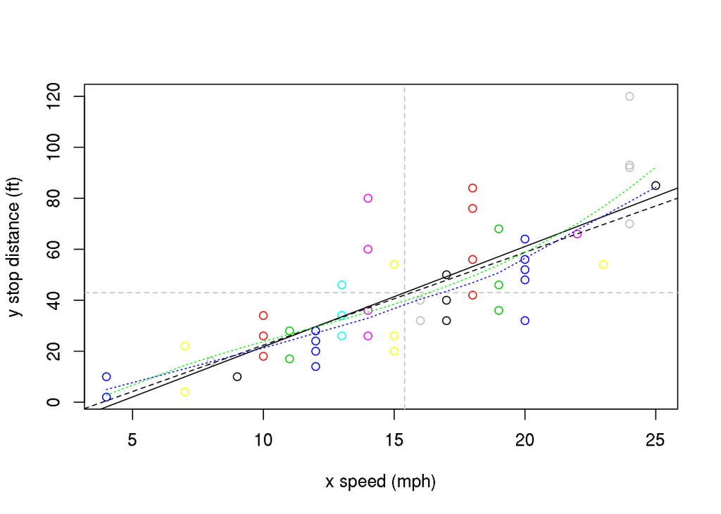

```r
plot(y ~ x, col=x, xlab="x speed (mph)", ylab="y stop distance (ft)")
abline(v=mean(x), h=mean(y), col="gray", lty=2)

abline(lm(y ~ x))
abline(lm(y ~ x, subset=(y < 100)), lty=2) # remove outlier
lines(x, predict(lm(y ~ x + I(x^2) + I(x^3)), list(x=x)), col="green", lty=3)
lines(lowess(x, y), col="blue", lty=3)
```

Grouped cars

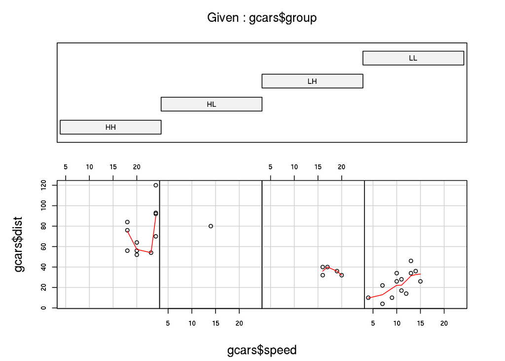

```r
coplot(gcars$dist ~ gcars$speed | gcars$group, panel=panel.smooth, rows=1)
```

```r
model1 <- lm(dist ~ speed, data=gcars)
model2 <- lm(dist ~ group, data=gcars)
model3 <- lm(dist ~ speed + group, data=gcars)
model4 <- lm(dist ~ speed * group, data=gcars)
anova(model1, model2, model3, model4) # RSS - residual ss
```

```
## Analysis of Variance Table
##
## Model 1: dist ~ speed
## Model 2: dist ~ group
## Model 3: dist ~ speed + group
## Model 4: dist ~ speed * group
##   Res.Df    RSS Df Sum of Sq      F   Pr(>F)
## 1     28 8896.6
## 2     26 6411.3  2   2485.35 6.1571 0.007219 **
## 3     25 4900.6  1   1510.69 7.4850 0.011778 *
## 4     23 4642.0  2    258.53 0.6405 0.536189
## ---
## Signif. codes:  0 '***' 0.001 '**' 0.01 '*' 0.05 '.' 0.1 ' ' 1
```

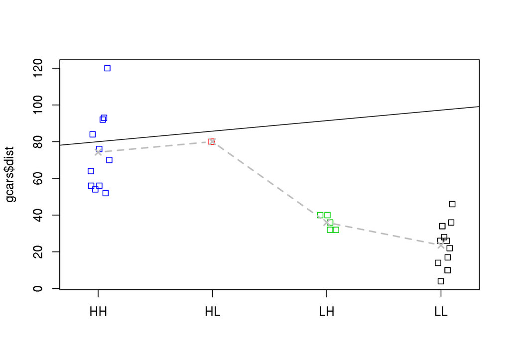

```r
stripchart(gcars$dist ~ gcars$group, data=gcars, vertical=TRUE, method="jitter", col=c(4,2,3,1))
suppressWarnings(abline(lm(dist ~ group, data=gcars)))
lines(1:length(levels(gcars$group)), tapply(gcars$dist, gcars$group, mean), type="b", pch=4, lty=2, lwd=2, col="gray")
```

## Confounding

Observed correlation of X and Y that is strictly depending on an extraneous variable Z (easy major in admissions example)

```r
d <- as.data.frame(UCBAdmissions)
a <- data.frame(Major = rep(LETTERS[1:6], 2), Gender = gl(2,6, labels=1:0), Number = 0, Percent = 0, NumberAccepted = 0, NumberRejected = 0)
for(G in 1:0) {
  for(M in LETTERS[1:6]) {
    m <- d[d$Gender == ifelse(G == 1, "Male", "Female"), ]
    s <- sum(m[m$Dept == M, "Freq"])
    ac <- m[m$Dept == M & m$Admit == "Admitted", "Freq"]
    rj <- m[m$Dept == M & m$Admit == "Rejected", "Freq"]
    a[a$Major == M & a$Gender == G, "Number"] <- s
    a[a$Major == M & a$Gender == G, "NumberAccepted"] <- ac
    a[a$Major == M & a$Gender == G, "NumberRejected"] <- rj
    a[a$Major == M & a$Gender == G, "Percent"] = round(ac * 100 / s)
  }
}
a
```

```
##    Major Gender Number Percent NumberAccepted NumberRejected
## 1      A      1    825      62            512            313
## 2      B      1    560      63            353            207
## 3      C      1    325      37            120            205
## 4      D      1    417      33            138            279
## 5      E      1    191      28             53            138
## 6      F      1    373       6             22            351
## 7      A      0    108      82             89             19
## 8      B      0     25      68             17              8
## 9      C      0    593      34            202            391
## 10     D      0    375      35            131            244
## 11     E      0    393      24             94            299
## 12     F      0    341       7             24            317
```

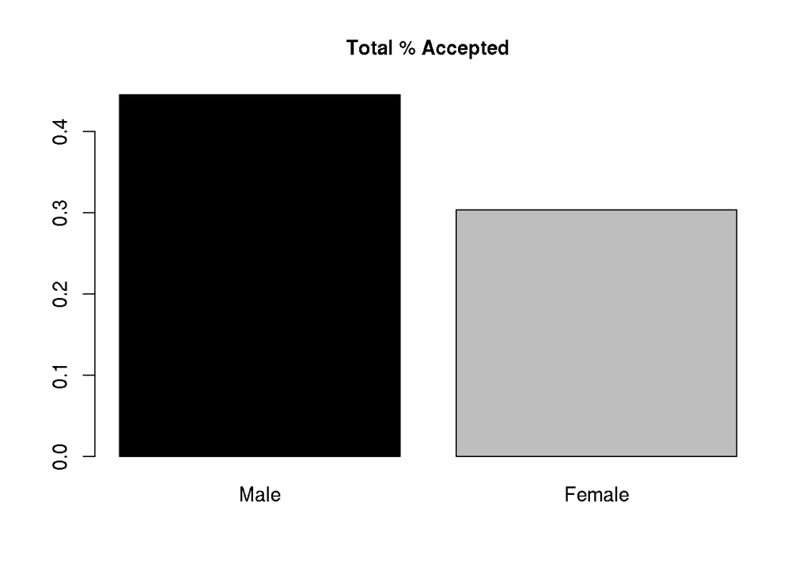

```r
index <- a$Gender==1
men <- a[index,]
women <- a[!index,]
menTotal <- sum(men$Number)
womenTotal <- sum(women$Number)
menYes <- sum(men$NumberAccepted)
menNo <- sum(men$NumberRejected)
womenYes <- sum(women$NumberAccepted)
womenNo <- sum(women$NumberRejected)

barplot(c(menYes / menTotal, womenYes / womenTotal),
        names.arg=c("Male", "Female"), main="Total % Accepted", col=c("black", "gray"))
```

```r
tab <- matrix(c(menYes, womenYes, menNo, womenNo), 2, 2)
chisq.test(tab)$p.val # reject null
```

```
## [1] 1.055797e-21
```

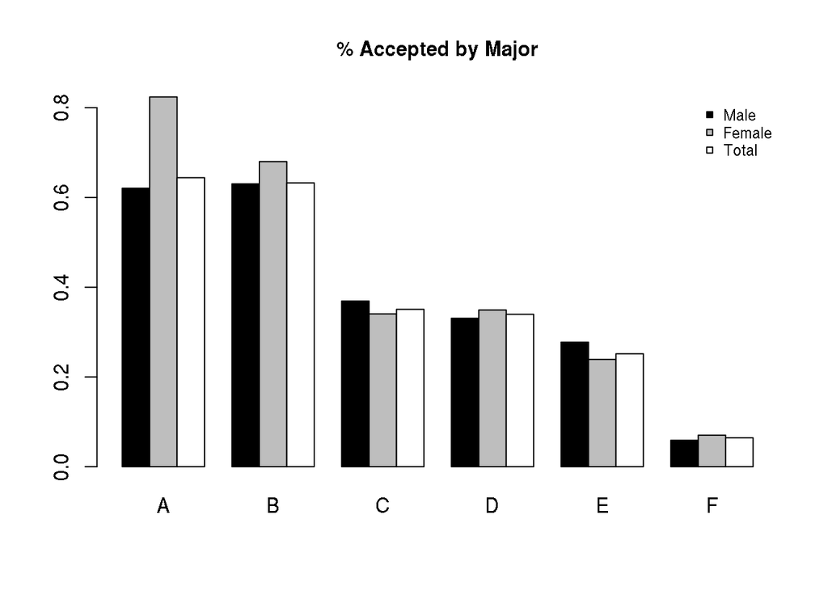

```r
#Simpson's paradox
stratified <- sapply(LETTERS[1:6], function(major){
  men <- a[index & a$Major == major,]
  women <- a[!index & a$Major == major,]
  m <- sum(men$NumberAccepted) / sum(men$Number)
  w <- sum(women$NumberAccepted) / sum(women$Number)
  t <- sum(a[a$Major == major,]$NumberAccepted) / sum(a[a$Major == major,]$Number)
  c(m,w,t)
})

barplot(stratified, beside=TRUE, col=c("black", "gray", "white"), main="% Accepted by Major")
legend("topright",c("Male","Female", "Total"), pt.bg=c("black", "gray", "white"), pch=22, box.lty=0, cex=0.75)
```

```r
tt <- as.data.frame(tapply(a$Percent, list(a$Major, a$Gender), sum))
tt$most <- ifelse(tt[,2] > tt[,1], 0, 1)
tt
```

```
##    1  0 most
## A 62 82    0
## B 63 68    0
## C 37 34    1
## D 33 35    0
## E 28 24    1
## F  6  7    0
```

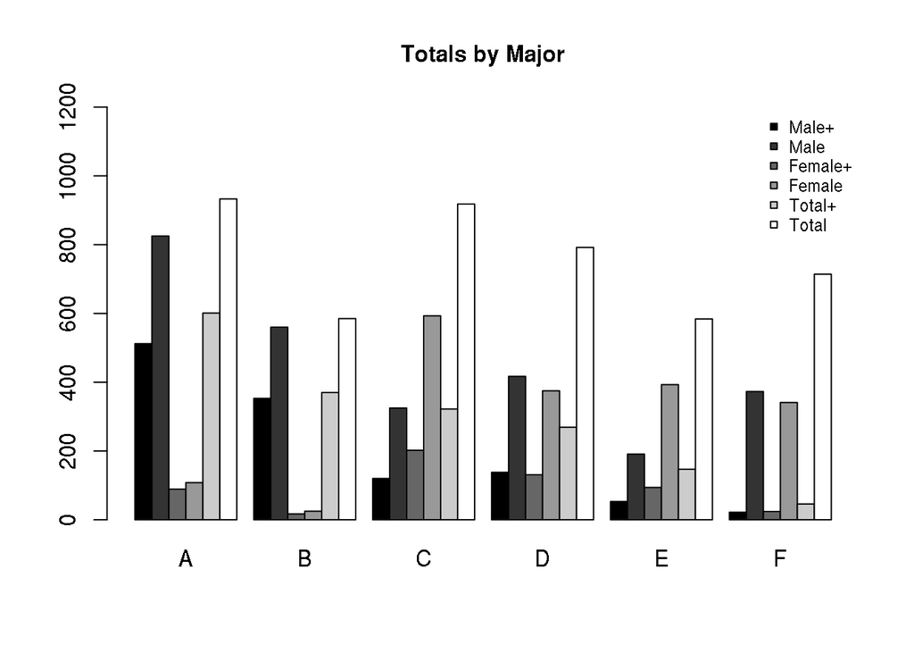

```r
stratified <- sapply(LETTERS[1:6], function(major){
  men <- a[index & a$Major == major,]
  women <- a[!index & a$Major == major,]
  c(sum(men$NumberAccepted), sum(men$Number),
    sum(women$NumberAccepted), sum(women$Number),
    sum(a[a$Major == major,]$NumberAccepted),
    sum(a[a$Major == major,]$Number)
    )
})

barplot(stratified, beside=TRUE, col=gray(0:5/5), main="Totals by Major", ylim=c(0, 1200))
legend("topright",c("Male+", "Male", "Female+","Female", "Total+", "Total"), pt.bg=gray(0:5/5), pch=22, box.lty=0, cex=0.75)
```

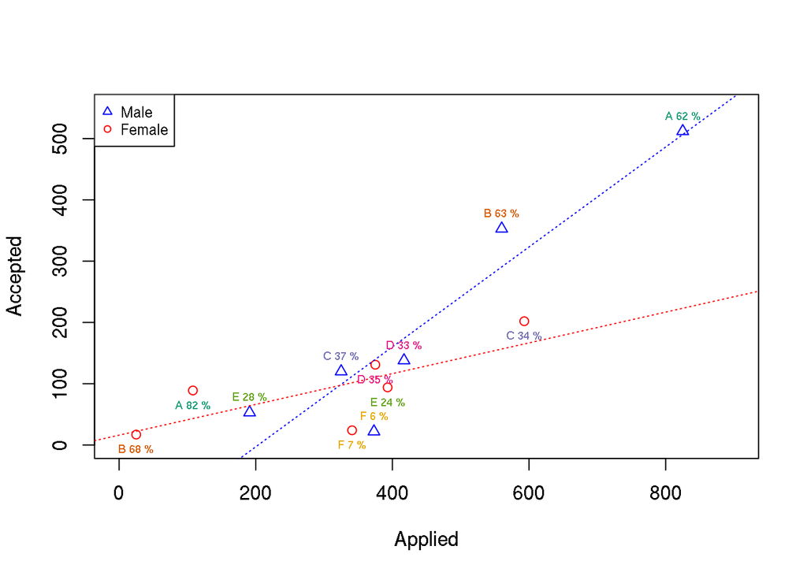

```r
library(RColorBrewer)
plot(men$Number, men$NumberAccepted, col="blue", ylim=c(0,550), xlim=c(0,900), xlab="Applied", ylab="Accepted", pch=2)
points(women$Number, women$NumberAccepted, col="red", pch=21)
legend("topleft",c("Male", "Female"), col=c("blue", "red"), pch=c(2, 21), cex=0.75)
abline(lm(men$NumberAccepted ~ men$Number), col="blue", lty=3)
abline(lm(women$NumberAccepted ~ women$Number), col="red", lty=3)
cc <- colorRampPalette(brewer.pal(6, "Dark2"))(6) #c(1,3,5,6,7,8)
text(men$Number, men$NumberAccepted, paste(men$Major, men$Percent, "%"), pos=3, col=cc, cex=0.7)
text(women$Number, women$NumberAccepted, paste(women$Major, women$Percent, "%"), pos=1, col=cc, cex=0.7)
```

**EOF**